# Cor-STRATES

Axel Arango

2022-11-03

Este es un ejemplo para realizar el framework correlated speciation and trait rates simulation (Cor-STRATES), propuesto en: Cooney, C.R., Thomas, G.H. Heterogeneous relationships between rates of speciation and body size evolution across vertebrate clades. Nat Ecol Evol 5, 101–110 (2021). https://doi.org/10.1038/s41559-020-01321-y

Cor-STRATES apunta a disminuir los errores y sesgos que pueden impactar negativamente los resultados de la relación entre la tasa de especiación y la tasa de evolución del carácter.

Este framework consta de tres partes: -Tasa de especiación -Tasa de evolución del carácter -Simulaciones y correlaciones

#1) Tasas de especiación

La primera parte (Tasa de especiación), puede ser obtenida de muchas maneras, aunque Cooney & Thomas recomiendan usar las tasas obtenidas por BAMM, también sugieren que en árboles pequeños DR funciona bien, y no prueban ClaDS; pero teorizan que podría ser mejor que BAMM.

En este caso usaremos la *media por rama* de las tasas de especiación obtenidas por BAMM para el ejercicio final, tal como lo hacen Cooney & Thomas.

Primero cargaremos los paquetes necesarios:

```r
library(BAMMtools)
library(phytools)
library(geiger)
library(RPANDA)
```

Después los datos necesarios:

```r
embtree<-read.tree("MCC_corrected_hwipruned.tre")
embtrait<-read.table("HWI_data_cap3_div.txt",header=F,sep="\t");names(embtrait)<-c("sp","hwi")
```

Cargados los paquetes, importaremos el objeto “event data” de BAMM.

```r
edata<-getEventData(phy = embtree,"BAMM_event_emberizo_capitulo3.txt",burnin = 0.1)
```

```
## Reading event datafile:  BAMM_event_emberizo_capitulo3.txt
##      ...........
## Read a total of 100 samples from posterior
##
## Discarded as burnin: GENERATIONS <  90000
## Analyzing  91  samples from posterior
##
## Setting recursive sequence on tree...
##
## Done with recursive sequence
```

Una vez teneniendo el “event data”, Cor-STRATES indica que debemos obtener la longitud de las ramas cómo valor de las tasas de especiación en el caso de BAMM.

Obteniendolas de las siguente manera:

```r
meanbranchtree<-getMeanBranchLengthTree(edata,rate = "speciation")


meanbranchrates<-meanbranchtree$phy$edge.length
head(meanbranchrates) #estas serían las tasas de especiación por rama para Emberizoidea
```

```
## [1] 0.9184761 0.4767351 0.2494827 0.1719776 0.1738514 0.1920207
```

Las tasas de especiación por rama también pueden ser obtenidas utilizando ClaDS (Maliet & Morlone, 2021;https://doi.org/10.1093/sysbio/syab055 ). -Las tasas de especacion de ClaDS deben ser calculadas primero utilizando PANDA en Julia-

```r
load("Clads_c3_1.Rdata")

#como default, el archivo obtenido usando ClaDS en julia, se llamará "CladsOutput"
clads_bl<-CladsOutput$lambdai_map
```

#2) Tasas de evolución fenótipica

Para la obtención de las tasas de evolución fenótipica, Cor-STRATES indica que primero, hay que calcular la señal filogenética del atributo de interés usando la *lambda* de Pagel.

Para eso utilizaremos la función *phylosig* de phytools.

```r
lambda<-phylosig(embtree,embtrait$hwi,method = "lambda",test = T,nsim = 1000)
```

```
## [1] "x has no names; assuming x is in the same order as tree$tip.label"
```

```r
lambda
```

```
##
## Phylogenetic signal lambda : 0.835198
## logL(lambda) : -2184.99
## LR(lambda=0) : 466.142
## P-value (based on LR test) : 2.21497e-103
```

Con la señal filogenética obtenida, utilizaremos el valor de lambda para reescalar el árbol filogenético

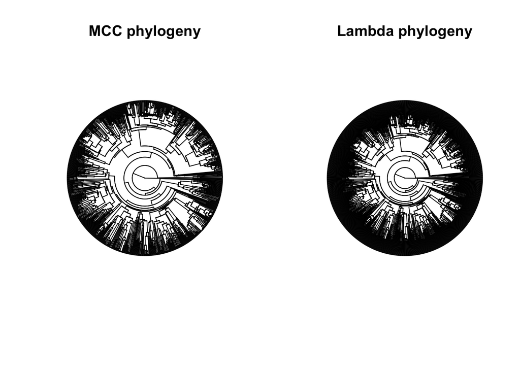

```r
rescalelambda<-rescale(embtree,model="lambda",lambda$lambda)
par(mfrow=c(1,2))
plot(embtree,show.tip.label =F,type = "fan",main="MCC phylogeny")
plot(rescalelambda,show.tip.label = F,type = "fan",main="Lambda phylogeny")
```

Ahora guardamos la filogenía reescalada, para futuros usos:

```r
write.tree(rescalelambda,"lambdatree.tre")
```

Utilizando la filogenia reescalada con los valores de lambda, se ajustarán los modelos de evolución fenótipica, ya sea con *BAMM* o *BayesTraits*

Para hacer esto con *BAMM*, primero calcularemos los priors. Los priors para evolución fenótipica deben incluir los valores observados del caracter, por lo tanto primero debemos cargarlos en forma vector con nombre

```r
phenotrait<-embtrait$hwi
names(phenotrait)<-embtrait$sp
phenoprior<-setBAMMpriors(phy = rescalelambda,832,traits =phenotrait,outfile = NULL )
```

Una vez calculados los priors, procederemos a crear un control file para el cálculo de BAMM:

```r
generateControlFile(file = "lambdacontrol.txt",type = "trait", params = list(
  treefile = 'lambdatree.tre',
  traitfile= 'HWI_data_cap3_div.txt',
    seed= '-1',
  eventDataOutfile= 'eventrait.txt',
    numberOfGenerations = '100000',
    overwrite = '1',
    betaInitPrior = as.numeric(phenoprior['betaInitPrior']),
     betaShiftPrior  = as.numeric(phenoprior['betaShiftPrior']),
    ObservedMinMaxAsTraitPriors = as.numeric(phenoprior['ObservedMinMaxAsTraitPriors']),
    expectedNumberOfShifts = '1',
  chainSwapFileName='chain_swap_trait.txt',
  mcmcOutfile='mcmc_out_trait.txt'))
```

Ya con el controlfile, podemos calcular *BAMM* fenótipico.

Ahora, con BayesTraits, estos deben calcularse con otra metódologia fuera de R, ver: http://www.evolution.reading.ac.uk/BayesTraitsV4.0.0/BayesTraitsV4.0.0.html.

Con BAMM, se debe cargar el objeto “event data” fenótipico, previamente calculado:

```r
tdata<-getEventData(phy = rescalelambda,"eventrait.txt",burnin = 0.1,type = 'trait')
```

```
## Reading event datafile:  eventrait.txt
##      ...........
## Read a total of 10000 samples from posterior
##
## Discarded as burnin: GENERATIONS <  999000
## Analyzing  9001  samples from posterior
##
## Setting recursive sequence on tree...
##
## Done with recursive sequence
```

Una vez cargado el objedo “event data” fenótipico, procederemos a calcular la longitud de rama promedio para obtener la tasa de evolución del caracter:

```r
traitbranchtree<-getMeanBranchLengthTree(tdata,rate = "trait")


traitranchrates<-traitbranchtree$phy$edge.length
head(traitranchrates)
```

```
## [1] 6.219592 5.068519 4.262354 3.650368 3.835038 3.391064
```

Ya con las tasas de especiación y las tasas de evolución fenótipica, realizaremos una correlación de spearman entre ambas tasas:

Se utiliza spearman debido a que la distribución de las tasas es altamente no-normal:

Dice Cooney & Thomas (2021): *“We used Spearman’s rank correlation (ρ) to measure the association between rates because the distribution of estimated speciation and/or trait rates is often highly non-normal, even after log transformation, which makes applying parametric statistics such as Pearson’s r problematic”.*

```r
obs.cor<-cor.test(log(meanbranchrates),log(traitranchrates),method = "spearman")
obs.cor
```

```
##
##  Spearman's rank correlation rho
##
## data:  log(meanbranchrates) and log(traitranchrates)
## S = 383756650, p-value < 2.2e-16
## alternative hypothesis: true rho is not equal to 0
## sample estimates:
##       rho
## 0.2897321
```

o utilizando ClaDS

```r
cl.cor<-cor.test(log(clads_bl),log(traitranchrates),method = "spearman")
cl.cor
```

```
##
##  Spearman's rank correlation rho
##
## data:  log(clads_bl) and log(traitranchrates)
## S = 423275160, p-value < 2.2e-16
## alternative hypothesis: true rho is not equal to 0
## sample estimates:
##     rho
## 0.21659
```

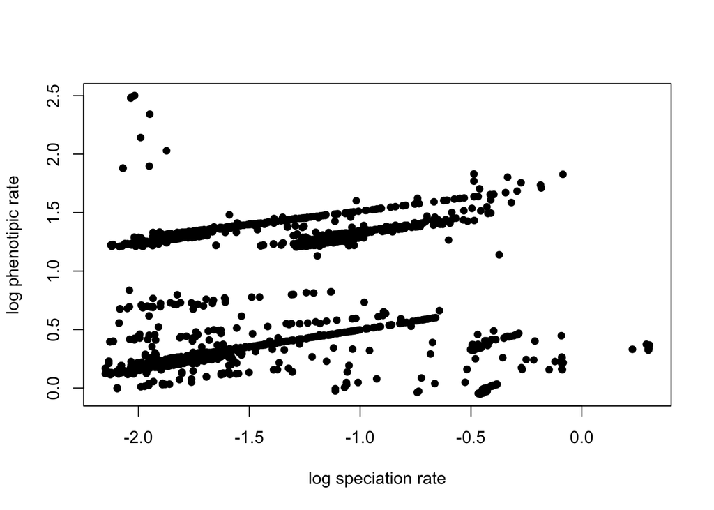

```r
plot(log(meanbranchrates),log(traitranchrates),xlab="log speciation rate",ylab=("log phenotipic rate"),pch=16)
```

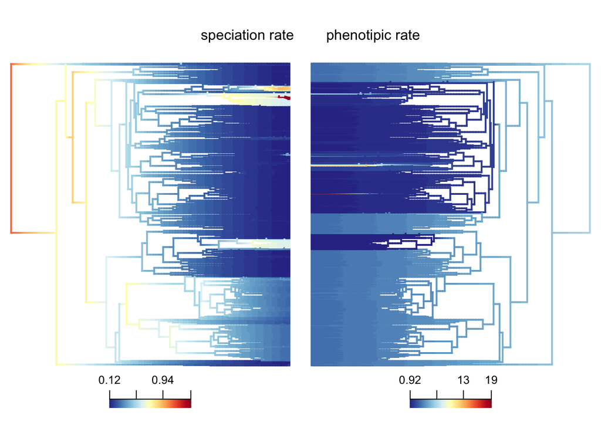

```r
par(mfrow=c(1,2),mar=c(3,0,3,0),xpd=T)
plotedata<-plot.bammdata(edata,lwd=2,direction = "rightwards")
addBAMMlegend(plotedata,location = "bottom")
legend("bottomright",inset=c(0,1),legend = "speciation rate",box.lwd = 0)
plottdata<-plot.bammdata(tdata,lwd=2,direction="leftwards")
addBAMMlegend(plottdata,location = "bottom",)
legend("bottomleft",inset=c(0,1),legend="phenotipic rate",box.lwd=0)
```

#Simulación de datasets nulos

Una vez observada la correlación entre la tasa de especación y la tasa de evolución fenótipica, craearemos datasets nulos simulando los valores del trait, para posteriormente ajustarles modelos de evolución fenótipica, y finalmente probar la significancia de la correlación observada, utilizando las correlaciones nulas.

Cor-STRATES utiliza datasets simulados bajo movimiento Browniano (BM), para esto primero se ajustará un modelo Browniano al atributo de interés, utilizando la filogenia reescalada.

```r
trait<-embtrait$hwi
names(trait)<-embtrait$sp
HWIBM<-fitContinuous(rescalelambda,trait,model = "BM")
```

Posteriormente, se utilizarán el valor de sigma cuadrado pbtenido del modelo BM ajustado, para simular los valores del atributo un número N de veces.

```r
sigsqz<-HWIBM$opt$sigsq
simus<-sim.char(rescalelambda,sigsqz,nsim=100,model="BM")
```

Finalmente, se escribirá cada simulación en archivos independientes, con la finalidad de ajustarles modelos de evolución fenótipica a cada uno, ya sea utilizando BAMM o BayesTraits.

```r
setwd("BM_sim/")
for(i in 1:100){
  simx<-simus[,,i]
  simx2<-as.data.frame(simx)
  names(simx2)<-NULL
  write.table(simx2,paste("BMSIM",i,".txt",sep = ""),sep="\t",col.names = F,row.names = T,quote = F)

}
```

Usando estos caracteres simulados, se calculan las tasas de evolución fenótipica simulada utilizando el prótocolo BAMM con los datos simulados.

Esto debería darnos (en nuestro caso) 100 archivos “Event Data” de evolución fenótipica, con datos simulados, los cuales se usarán para calcular las correlaciones nulas:

```r
nullcors<-data.frame()

#nullrates<-data.frame()
for (i in 1:100){
  sdata<-getEventData(phy = rescalelambda,paste0("Sims/ES",i,".txt"),burnin = 0.1,type = 'trait',verbose = F)
  print(i)
  simbranchtree<-getMeanBranchLengthTree(sdata,rate = "trait")
  simbranchrates<-simbranchtree$phy$edge.length
  ncor<-cor.test(log(meanbranchrates),log(simbranchrates),method = "spearman")
  nrho<-ncor$estimate
  print(nrho)
  names(nrho)<-"Rho"
  nullcors<-rbind(nullcors,nrho)


}
sim.cor<-nullcors
names(sim.cor)<-"Rho"
```

Ahora, calcularemos el p valor de la correlación observada en relación con las correlaciones nulas

```r
sim.corx<-sim.cor$Rho
sims<-100
upper <- (length(sim.corx[sim.corx >= obs.cor$estimate])+1)/(sims+1)
  lower <- (length(sim.corx[sim.corx <= obs.cor$estimate])+1)/(sims+1)
  pval <- 2*min(c(upper,lower))
  if (pval == 0) { pval <- 2*(1/sims) }
  cis <- quantile(sim.corx, probs = c(0.025, 0.975))
  ses <- (obs.cor$estimate - mean(sim.corx)) / sd(sim.corx)
  out <- c(obs.cor$estimate, mean(sim.corx), cis[1], cis[2], pval, ses)
  names(out) <- c("obs.cor", "sim.cor.mean", "sim.cor.lci", "sim.cor.uci", "pval", "ses")



out
```

```
##      obs.cor sim.cor.mean  sim.cor.lci  sim.cor.uci         pval          ses
##    0.2897321   -0.3029550   -0.3917119    0.3162362    0.1386139    3.3416480
```

Desafortunadamente, parece que la tasa de evolución fenótipica, a pesar de estár correlacionada con la especiación, no es diferente de lo que se esperaría por estócasticidad.

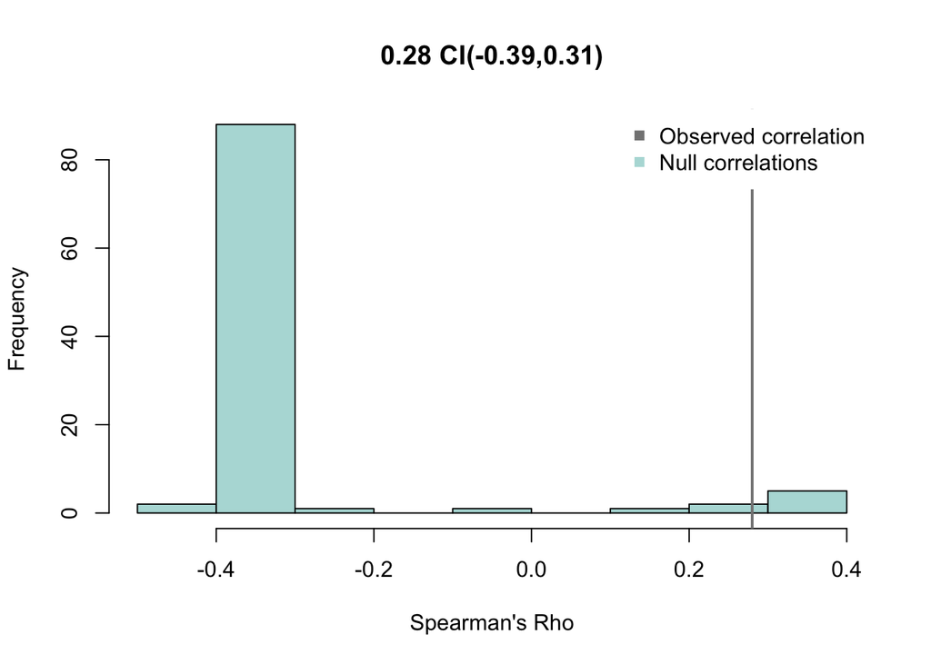

```r
hist(sim.cor$Rho,main="0.28 CI(-0.39,0.31)",xlab="Spearman's Rho",col="#B4DCDA")
abline(v=0.28,col="#848484",lwd=2)
legend(x="topright",legend = c("Observed correlation", "Null correlations"),pch = 15,cex=1, col= c("#848484","#B4DCDA"),box.col = "white")
```